# Model building: red and white wine

```r
library(tidyverse)
library(modelr)
library(GGally)
```

Let’s start analysing the data-sets

```r
red_wines <- read_csv("data/wine_quality_red.csv")
white_wines <- read_csv("data/wine_quality_white.csv")
```

```r
glimpse(red_wines)
```

```
Rows: 1,599
Columns: 14
$ wine_id              <dbl> 1, 2, 3, 4, 5, 6, 7, 8, 9, 10, 11, 12, 13, 14, 15, 16, 17, 18, 19, 20, 21, 22, 23, 24, 25, 26, 27, 28, 29, 30, …
$ fixed_acidity        <dbl> 7.4, 7.8, 7.8, 11.2, 7.4, 7.4, 7.9, 7.3, 7.8, 7.5, 6.7, 7.5, 5.6, 7.8, 8.9, 8.9, 8.5, 8.1, 7.4, 7.9, 8.9, 7.6, …
$ volatile_acidity     <dbl> 0.700, 0.880, 0.760, 0.280, 0.700, 0.660, 0.600, 0.650, 0.580, 0.500, 0.580, 0.500, 0.615, 0.610, 0.620, 0.620,…
$ citric_acid          <dbl> 0.00, 0.00, 0.04, 0.56, 0.00, 0.00, 0.06, 0.00, 0.02, 0.36, 0.08, 0.36, 0.00, 0.29, 0.18, 0.19, 0.56, 0.28, 0.0…
$ residual_sugar       <dbl> 1.9, 2.6, 2.3, 1.9, 1.9, 1.8, 1.6, 1.2, 2.0, 6.1, 1.8, 6.1, 1.6, 1.6, 3.8, 3.9, 1.8, 1.7, 4.4, 1.8, 1.8, 2.3, 1…
$ chlorides            <dbl> 0.076, 0.098, 0.092, 0.075, 0.076, 0.075, 0.069, 0.065, 0.073, 0.071, 0.097, 0.071, 0.089, 0.114, 0.176, 0.170,…
$ free_sulfur_dioxide  <dbl> 11, 25, 15, 17, 11, 13, 15, 15, 9, 17, 15, 17, 16, 9, 52, 51, 35, 16, 6, 17, 29, 23, 10, 9, 21, 11, 4, 10, 14, …
$ total_sulfur_dioxide <dbl> 34, 67, 54, 60, 34, 40, 59, 21, 18, 102, 65, 102, 59, 29, 145, 148, 103, 56, 29, 56, 60, 71, 37, 67, 40, 23, 11…
$ density              <dbl> 0.9978, 0.9968, 0.9970, 0.9980, 0.9978, 0.9978, 0.9964, 0.9946, 0.9968, 0.9978, 0.9959, 0.9978, 0.9943, 0.9974,…
$ p_h                  <dbl> 3.51, 3.20, 3.26, 3.16, 3.51, 3.51, 3.30, 3.39, 3.36, 3.35, 3.28, 3.35, 3.58, 3.26, 3.16, 3.17, 3.30, 3.11, 3.3…
$ sulphates            <dbl> 0.56, 0.68, 0.65, 0.58, 0.56, 0.56, 0.46, 0.47, 0.57, 0.80, 0.54, 0.80, 0.52, 1.56, 0.88, 0.93, 0.75, 1.28, 0.5…
$ alcohol              <dbl> 9.4, 9.8, 9.8, 9.8, 9.4, 9.4, 9.4, 10.0, 9.5, 10.5, 9.2, 10.5, 9.9, 9.1, 9.2, 9.2, 10.5, 9.3, 9.0, 9.2, 9.4, 9.…
$ quality              <dbl> 4.66, 4.82, 4.91, 5.96, 5.42, 4.78, 5.09, 6.78, 7.10, 4.78, 5.22, 5.50, 5.44, 5.13, 5.30, 4.85, 6.61, 4.67, 4.4…
$ region               <chr> "Australia", "Spain", "Spain", "Australia", "Italy", "Italy", "USA", "Italy", "USA", "Australia", "Australia", …
```

```r
glimpse(white_wines)
```

```
Rows: 4,898
Columns: 14
$ wine_id              <dbl> 1, 2, 3, 4, 5, 6, 7, 8, 9, 10, 11, 12, 13, 14, 15, 16, 17, 18, 19, 20, 21, 22, 23, 24, 25, 26, 27, 28, 29, 30, …
$ fixed_acidity        <dbl> 7.0, 6.3, 8.1, 7.2, 7.2, 8.1, 6.2, 7.0, 6.3, 8.1, 8.1, 8.6, 7.9, 6.6, 8.3, 6.6, 6.3, 6.2, 7.4, 6.5, 6.2, 6.4, 6…
$ volatile_acidity     <dbl> 0.27, 0.30, 0.28, 0.23, 0.23, 0.28, 0.32, 0.27, 0.30, 0.22, 0.27, 0.23, 0.18, 0.16, 0.42, 0.17, 0.48, 0.66, 0.3…
$ citric_acid          <dbl> 0.36, 0.34, 0.40, 0.32, 0.32, 0.40, 0.16, 0.36, 0.34, 0.43, 0.41, 0.40, 0.37, 0.40, 0.62, 0.38, 0.04, 0.48, 0.4…
$ residual_sugar       <dbl> 20.70, 1.60, 6.90, 8.50, 8.50, 6.90, 7.00, 20.70, 1.60, 1.50, 1.45, 4.20, 1.20, 1.50, 19.25, 1.50, 1.10, 1.20, …
$ chlorides            <dbl> 0.045, 0.049, 0.050, 0.058, 0.058, 0.050, 0.045, 0.045, 0.049, 0.044, 0.033, 0.035, 0.040, 0.044, 0.040, 0.032,…
$ free_sulfur_dioxide  <dbl> 45, 14, 30, 47, 47, 30, 30, 45, 14, 28, 11, 17, 16, 48, 41, 28, 30, 29, 17, 34, 29, 19, 41, 25, 16, 56, 35, 32,…
$ total_sulfur_dioxide <dbl> 170, 132, 97, 186, 186, 97, 136, 170, 132, 129, 63, 109, 75, 143, 172, 112, 99, 75, 171, 133, 75, 102, 122, 168…
$ density              <dbl> 1.0010, 0.9940, 0.9951, 0.9956, 0.9956, 0.9951, 0.9949, 1.0010, 0.9940, 0.9938, 0.9908, 0.9947, 0.9920, 0.9912,…
$ p_h                  <dbl> 3.00, 3.30, 3.26, 3.19, 3.19, 3.26, 3.18, 3.00, 3.30, 3.22, 2.99, 3.14, 3.18, 3.54, 2.98, 3.25, 3.24, 3.33, 3.1…
$ sulphates            <dbl> 0.45, 0.49, 0.44, 0.40, 0.40, 0.44, 0.47, 0.45, 0.49, 0.45, 0.56, 0.53, 0.63, 0.52, 0.67, 0.55, 0.36, 0.39, 0.5…
$ alcohol              <dbl> 8.8, 9.5, 10.1, 9.9, 9.9, 10.1, 9.6, 8.8, 9.5, 11.0, 12.0, 9.7, 10.8, 12.4, 9.7, 11.4, 9.6, 12.8, 11.3, 9.5, 12…
$ quality              <dbl> 5.92, 6.06, 6.25, 6.38, 6.35, 5.82, 5.53, 6.17, 6.08, 5.86, 4.91, 5.48, 4.94, 6.92, 5.09, 7.29, 6.40, 8.14, 5.7…
$ region               <chr> "Australia", "Australia", "Spain", "Spain", "USA", "Italy", "Australia", "Australia", "Italy", "USA", "Spain", …
```

## Familiarising ourselves with the data and the problem:

Each row of the dataset contains informations about a single wine.

Because both the data-sets has the same column, as a first thing I will create a unique data-set adding them together.

```r
wine_r <- rep("red_wine", nrow(red_wines))

red_wines <- red_wines %>%
  bind_cols(wine = wine_r)


wine_w <- rep("white_wine", nrow(white_wines))

white_wines <- white_wines %>%
  bind_cols(wine = wine_w)


wines <- bind_rows(red_wines, white_wines)
```

Our aim is to create an explanatory model for the quality of the wines!

```r
names(wines)
```

```
 [1] "wine_id"              "fixed_acidity"        "volatile_acidity"     "citric_acid"          "residual_sugar"       "chlorides"
 [7] "free_sulfur_dioxide"  "total_sulfur_dioxide" "density"              "p_h"                  "sulphates"            "alcohol"
[13] "quality"              "region"               "wine"
```

```r
skimr::skim(wines)
```

```
── Data Summary ────────────────────────
                           Values
Name                       wines
Number of rows             6497
Number of columns          15
_______________________
Column type frequency:
  character                2
  numeric                  13
________________________
Group variables            None
```

|  | skim_variable | n_missing | complete_rate | min | max | empty | n_unique | whitespace |
| --- | --- | --- | --- | --- | --- | --- | --- | --- |
| 1 | region | 0 | 1 | 3 | 9 | 0 | 5 | 0 |
| 2 | wine | 0 | 1 | 8 | 10 | 0 | 2 | 0 |

|  | skim_variable | n_missing | complete_rate | mean | sd | p0 | p25 | p50 | p75 | p100 | hist |
| --- | --- | --- | --- | --- | --- | --- | --- | --- | --- | --- | --- |
| 1 | wine_id | 0 | 1 | 2.043536e+03 | 1.436926e+03 | 1.00000 | 813.00000 | 1650.00000 | 3274.00000 | 4898.00000 | ▇▆▃▃▃ |
| 2 | fixed_acidity | 0 | 1 | 7.215307e+00 | 1.296434e+00 | 3.80000 | 6.40000 | 7.00000 | 7.70000 | 15.90000 | ▂▇▁▁▁ |
| 3 | volatile_acidity | 0 | 1 | 3.396660e-01 | 1.646365e-01 | 0.08000 | 0.23000 | 0.29000 | 0.40000 | 1.58000 | ▇▂▁▁▁ |
| 4 | citric_acid | 0 | 1 | 3.186332e-01 | 1.453179e-01 | 0.00000 | 0.25000 | 0.31000 | 0.39000 | 1.66000 | ▇▅▁▁▁ |
| 5 | residual_sugar | 0 | 1 | 5.443235e+00 | 4.757804e+00 | 0.60000 | 1.80000 | 3.00000 | 8.10000 | 65.80000 | ▇▁▁▁▁ |
| 6 | chlorides | 0 | 1 | 5.603386e-02 | 3.503360e-02 | 0.00900 | 0.03800 | 0.04700 | 0.06500 | 0.61100 | ▇▁▁▁▁ |
| 7 | free_sulfur_dioxide | 0 | 1 | 3.052532e+01 | 1.774940e+01 | 1.00000 | 17.00000 | 29.00000 | 41.00000 | 289.00000 | ▇▁▁▁▁ |
| 8 | total_sulfur_dioxide | 0 | 1 | 1.157446e+02 | 5.652185e+01 | 6.00000 | 77.00000 | 118.00000 | 156.00000 | 440.00000 | ▅▇▂▁▁ |
| 9 | density | 0 | 1 | 9.946966e-01 | 2.998673e-03 | 0.98711 | 0.99234 | 0.99489 | 0.99699 | 1.03898 | ▇▂▁▁▁ |
| 10 | p_h | 0 | 1 | 3.218501e+00 | 1.607872e-01 | 2.72000 | 3.11000 | 3.21000 | 3.32000 | 4.01000 | ▁▇▆▁▁ |

[output cut: 3 more lines]

- Most of the variables of type double seems to be right skewed, which means that could be useful to apply some sort of transformation (like logarithm or square roots) to them. However, there are also variables like `p_h`, `alcohol` and `quality` that seems to be quite normally distributed.
- There are no missing values in any of the variables.

## Prepare the data for Analysis

There are a few columns that are of type double, but should instead be categorical: such as “wine_id”, “p_h”. I am going to change their type in ‘factor’.

```r
wines <- wines %>%
  mutate(wine_id, wine_id = as.factor(wine_id))
```

The ‘wine_id’ column identyfy the specific wine. It seems not to be interesting for determining its quality, so I will remove it.

```r
wines <- wines %>%
  select(-wine_id)
```

Let’s have a look of the `region` column.

| region |
| --- |
| Australia |
| Spain |
| Italy |
| USA |
| France |

There are 5 regions involved, which would produce 4 dummy variables. I will analyse the ‘ggpair’ before deciding what to do with this column.

```r
wines <- wines %>%
  mutate(p_h = case_when(
    p_h < 3 ~ "2-3",
    p_h < 4 ~ "3-4",
    p_h >= 4 ~ "4+"
  ))
```

| fixed_acidity |
| --- |
| 3.80 |
| 3.90 |
| 4.20 |
| 4.40 |
| 4.50 |
| 4.60 |
| 4.70 |
| 4.80 |
| 4.90 |
| 5.00 |

[output cut: 96 more lines]

```r
wines <- wines %>%
  mutate(volatile_acidity = case_when(
    volatile_acidity < 0.5 ~ "less 0.5",
    volatile_acidity < 1 ~ "0.5-1",
    volatile_acidity >= 1 ~ "more 1"
  ))
```

I am going to create a train and test set

| fixed_acidity | volatile_acidity | citric_acid | residual_sugar | chlorides | free_sulfur_dioxide | total_sulfur_dioxide | density | p_h | sulphates | alcohol | quality | region | wine |
| --- | --- | --- | --- | --- | --- | --- | --- | --- | --- | --- | --- | --- | --- |
| 5-10 | 0.5-1 | 0.00 | 2.60 | 0.098 | 25.0 | 67 | 0.99680 | 3-4 | 0.68 | 9.8 | 4.82 | Spain | red_wine |
| 5-10 | 0.5-1 | 0.04 | 2.30 | 0.092 | 15.0 | 54 | 0.99700 | 3-4 | 0.65 | 9.8 | 4.91 | Spain | red_wine |
| 10-16 | less 0.5 | 0.56 | 1.90 | 0.075 | 17.0 | 60 | 0.99800 | 3-4 | 0.58 | 9.8 | 5.96 | Australia | red_wine |
| 5-10 | 0.5-1 | 0.00 | 1.90 | 0.076 | 11.0 | 34 | 0.99780 | 3-4 | 0.56 | 9.4 | 5.42 | Italy | red_wine |
| 5-10 | 0.5-1 | 0.00 | 1.80 | 0.075 | 13.0 | 40 | 0.99780 | 3-4 | 0.56 | 9.4 | 4.78 | Italy | red_wine |
| 5-10 | 0.5-1 | 0.06 | 1.60 | 0.069 | 15.0 | 59 | 0.99640 | 3-4 | 0.46 | 9.4 | 5.09 | USA | red_wine |
| 5-10 | 0.5-1 | 0.00 | 1.20 | 0.065 | 15.0 | 21 | 0.99460 | 3-4 | 0.47 | 10.0 | 6.78 | Italy | red_wine |
| 5-10 | 0.5-1 | 0.02 | 2.00 | 0.073 | 9.0 | 18 | 0.99680 | 3-4 | 0.57 | 9.5 | 7.10 | USA | red_wine |
| 5-10 | 0.5-1 | 0.36 | 6.10 | 0.071 | 17.0 | 102 | 0.99780 | 3-4 | 0.80 | 10.5 | 4.78 | Australia | red_wine |
| 5-10 | 0.5-1 | 0.08 | 1.80 | 0.097 | 15.0 | 65 | 0.99590 | 3-4 | 0.54 | 9.2 | 5.22 | Australia | red_wine |

[output cut: 990 more lines]

```r
wines_num <- wines %>%
  select_if(is.numeric)

wines_cat <- wines %>%
  select_if(function(x) !is.numeric(x))


wines_cat$quality <- wines$quality
```

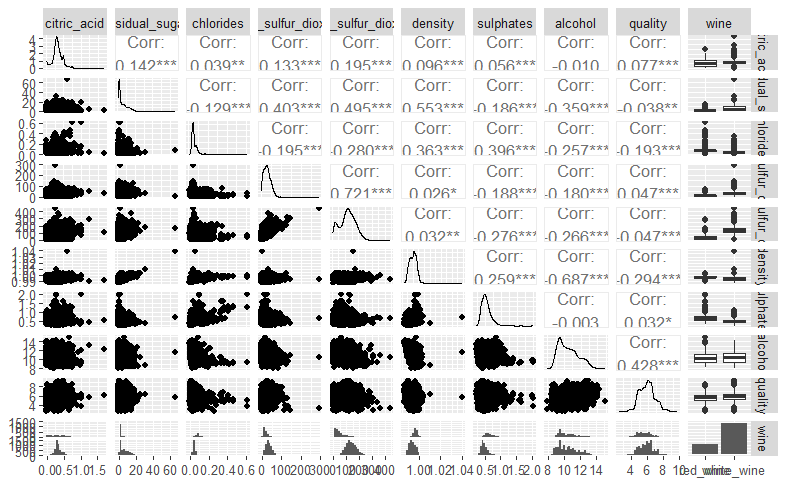

```r
ggpairs(wines_num, progress = FALSE)
```

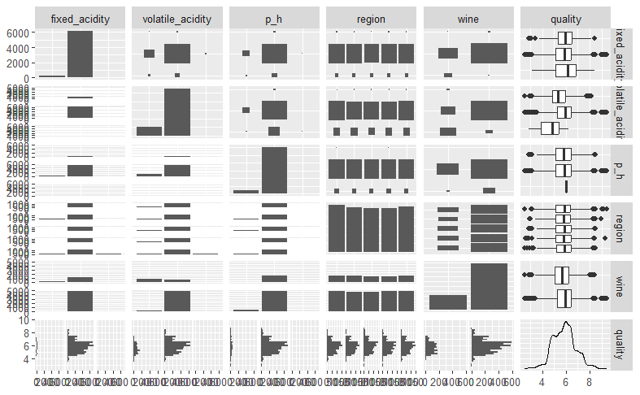

```r
ggpairs(wines_cat, progress = FALSE)
```

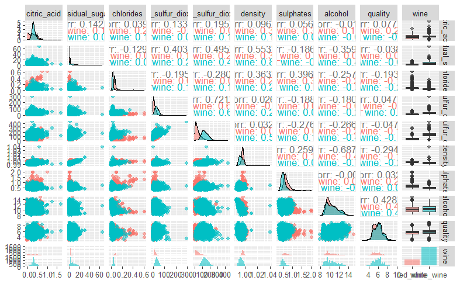

```r
ggpairs(wines_num, progress = FALSE, aes(colour = wine, alpha = 0.5))
```

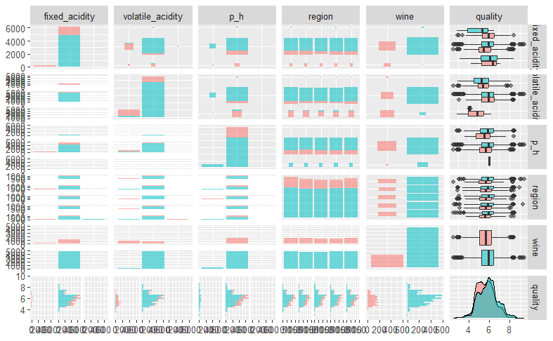

```r
ggpairs(wines_cat, progress = FALSE, aes(colour = wine, alpha = 0.5))
```

- For the categorical variables it seems that the `volatile_acidity` present significant variation for one of the three categoeries with respect to the others.
- I wouldn’t consider the `region` feature since it produce 4 dummy variables and it doesn’t seems to give too much significance to the analysis.
- For the continuous variables, I would consider the `alcohol` which seems to be strongly correlated.
- Furthermore, I would consider the `wine` feature, since it seems there is a significant difference between red and white wines.

```r
model <- lm(quality, alcohol + wine + volatile_acidity, train)
```

[output not shown]

```r
predictions_test <- test %>%
  add_predictions(model) %>%
  select(quality, pred)
```

```r
mse_test <- mean((predictions_test$pred - test$quality)**2)
mse_test
```

```
[1] 0.6640965
```

It seems from the error that the model is well proportioned.

```r
summary(model)
```

[output not shown]

| wine |
| --- |
| red_wine |
| white_wine |

```r
model_2 <- lm(quality ~ alcohol * wine + volatile_acidity * wine, train)
```

```r
predictions_test_2 <- test %>%
  add_predictions(model_2) %>%
  select(quality, pred)
```

```r
mse_test <- mean((predictions_test_2$pred - test$quality)**2)
mse_test
```

```
[1] 0.6635645
```

```r
summary(model_2)
```

```
Call:
lm(formula = quality ~ alcohol * wine + volatile_acidity * wine,
    data = train)

Residuals:
    Min      1Q  Median      3Q     Max
-3.5365 -0.5564 -0.0235  0.5328  3.2731

Coefficients:
                                        Estimate Std. Error t value Pr(>|t|)
(Intercept)                              1.98829    0.22457   8.854  < 2e-16 ***
alcohol                                  0.34225    0.02177  15.719  < 2e-16 ***
winewhite_wine                          -0.10116    0.25959  -0.390  0.69677
volatile_acidityless 0.5                 0.27721    0.04742   5.846 5.34e-09 ***
volatile_aciditymore 1                  -0.64112    0.19576  -3.275  0.00106 **
alcohol:winewhite_wine                  -0.01948    0.02423  -0.804  0.42151
winewhite_wine:volatile_acidityless 0.5  0.35573    0.08404   4.233 2.34e-05 ***
winewhite_wine:volatile_aciditymore 1   -0.12826    0.84558  -0.152  0.87944
---
Signif. codes:  0 ‘***’ 0.001 ‘**’ 0.01 ‘*’ 0.05 ‘.’ 0.1 ‘ ’ 1

Residual standard error: 0.8198 on 5190 degrees of freedom
Multiple R-squared:  0.2167,    Adjusted R-squared:  0.2157
F-statistic: 205.1 on 7 and 5190 DF,  p-value: < 2.2e-16
```

The fact that the wine is red or white it seems not statistically significant since the number of white wines analysed here is significantly higher than the number of red wines.

```r
model_3 <- lm(quality ~ alcohol + volatile_acidity, train)
```

```r
predictions_test_3 <- test %>%
  add_predictions(model_3) %>%
  select(quality, pred)
```

```r
mse_test <- mean((predictions_test_3$pred - test$quality)**2)
mse_test
```

```
[1] 0.6640319
```

```r
summary(model_3)
```

```
Call:
lm(formula = quality ~ alcohol + volatile_acidity, data = train)

Residuals:
    Min      1Q  Median      3Q     Max
-3.5327 -0.5480 -0.0204  0.5371  3.2796

Coefficients:
                          Estimate Std. Error t value Pr(>|t|)
(Intercept)               2.112847   0.102064  20.701  < 2e-16 ***
alcohol                   0.324893   0.009559  33.990  < 2e-16 ***
volatile_acidityless 0.5  0.378653   0.031261  12.113  < 2e-16 ***
volatile_aciditymore 1   -0.610437   0.190486  -3.205  0.00136 **
---
Signif. codes:  0 ‘***’ 0.001 ‘**’ 0.01 ‘*’ 0.05 ‘.’ 0.1 ‘ ’ 1

Residual standard error: 0.8209 on 5194 degrees of freedom
Multiple R-squared:  0.2139,    Adjusted R-squared:  0.2135
F-statistic: 471.1 on 3 and 5194 DF,  p-value: < 2.2e-16
```